# Advanced Visualizations Lecture 05

## 2.2.0 Plot your k-means results with `fviz_cluster()`

Rather than use `ggplot` directly, we’ll use the ggplot-compatible `fviz_cluster()` function to help us transform the values of our points from a 4258-dimension coordinate system to a 2-dimension visual format suitable for our simpler brains. Under the hood `fviz_cluster()` is performing a principle component analysis to group our `data` along the first two principal components (more on what that means later too!).

The parameters we should be concerned with in this function include:

- `object` the partitioning object for our data. In the case of k-means, it is our kmeans object.
- `data` is the original dataset we used to generate the data. This will be necessary to plot the other data points.
- `ellipse.type` determines how we’ll outline our clusters. This comes with a number of options including:
  - convex: draws boundaries based on the outer points in your cluster
  - confidence: produces a confidence ellipse around the cluster centres. This can be further adjusted using the parameter `ellipse.level` whose default is 0.95.
  - t, norm: assume multivariate t-distribution and multivariate normal distributions to produce their ellipses using `ellipse.level` to set their radius.
  - euclid: sets a circle of radius `ellipse.level` around the centre of each cluster.

**K-means vs PCA:** It’s important to remember what is happening in this next step. We have **already** grouped our 83 samples based on a k-means algorithm. Those groupings are represented within our `kmeans` object. To **visualize** our datapoint, we are using principal component analysis to help *project* the complex n-dimensional data onto a 2-dimensional plane. The **colouring and fencing** of the datapoints in the plot comes from data within the `kmeans` object!

Let’s see how our data has been partitioned by the k-means clustering.

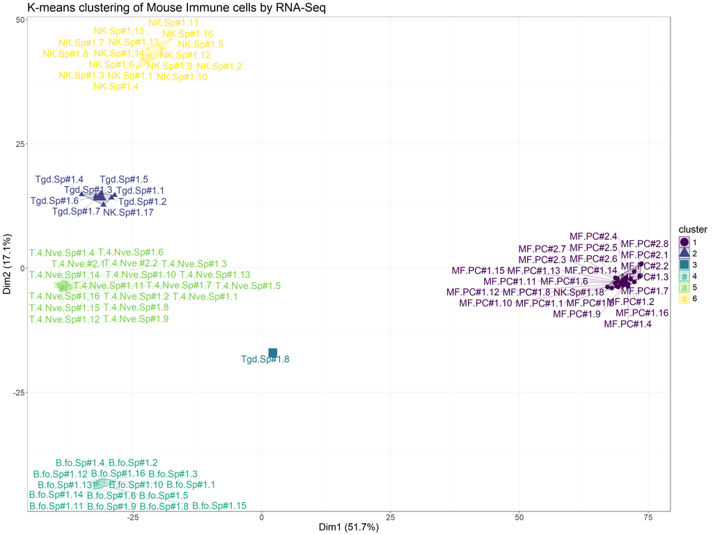

```r
# Plot the cluster
# You can treat this object like a ggplot object afterwards

rnaseq_kmeans.plot <-

  fviz_cluster(object = rnaSeq.km, # our k-means object
               data = t(rnaSeq.mx), # Our original data needed for PCA to visualize
               ellipse.type = "convex",
               ggtheme = theme_bw(),
               repel=TRUE, # Try to avoid overlapping text
               labelsize = 20,
               pointsize = 4,
               main = "K-means clustering of Mouse Immune cells by RNA-Seq"
               ) +

  # Set some ggplot theme information
  theme(text = element_text(size=20)) +

  # Set the colour and fill scheme to viridis
  scale_fill_viridis_d() +
  scale_colour_viridis_d()

# Print the plot!
rnaseq_kmeans.plot
```

**Skeptic or believer?** While our above analysis seems to make sense to us, it lacks a deeper understanding of why these groupings were chosen. For one thing, we haven’t even looked closely at the genes used to create our clustering. How many of them are relevant to each class of immune cells? What is the cause of our off-target cells? While clustering is an effective way to quickly identify if subgroups exist within your data, it’s important to follow up these findings with in-depth analyses of the data.

[figure not shown]

Yes the data clusters, but why does it cluster?

# 3.0.0 Dimension reduction trims the (data) fat

One problem we encountered in our above analysis of RNA-Seq data is that there were simply too many dimensions! With ~55k gene entries in the original dataset, using clustering to analyse the entire dataset would be memory-intensive if not impossible altogether. To circumvent this problem we attempted to subset our data, filtering by read counts. We could have also use the overall variance in each gene as a means of ordering our data and filtering it! These approaches are a form of *dimensionality reduction* - namely feature elimination. Our choices, however, may have inadvertently been throwing away data that could prove insightful! This is where other dimensionality reduction methods can help guide our analyses.

You can achieve dimensionality reduction in three general ways:

1. **Feature elimination**: you can reduce the feature space by removing unhelpful features. No information is gained but you trim down your dataset size.
2. **Feature selection**: on the reverse side you can simply choose the most important features to you. How will you decide? Some schemes include ranking your features by importance but this may suffer from information loss if incorrect features are chosen.
3. **Feature extraction**: create new independent features which are a combination of the old features! Attempt to extract the essential features of your data in a more information-dense manner.

| Technique | Description | Type | Useful for |
| --- | --- | --- | --- |
| Random forest | Popular machine learning algorithm for classification randomly chooses from subsets of features to classify data. The most frequently appearing features amongst the forests are chosen. | Feature selection | Only takes numeric inputs |
| PCA | Principal component analysis attempts to maximize variation when transforming to a lower-dimensional space. All new features are independent of one another. | Linear Feature Extraction | Actually really good at finding outliers in RNAseq data |
| PCoA | Principal Coordinate analysis uses distance matrices rather than raw feature values. These distance matrices represent the pairwise dissimilarities between objects but they are very dependent upon the… | Linear Feature extraction | Microbial community composition analysis |
| t-SNE | t-Distributed Stochastic Neighbour Embedding is a non-linear technique similar to PCA suitable for high-dimension datasets. It attempts to minimize probabilities in mirroring nearest neighbour relatio… | Non-linear Feature extraction | Determine if your data has underlying structure |
| UMAP | Uniform manifold approximation and projection is projection-based like t-SNE, this technique attempts to preserve local data structure but has improved translation of global data structure. | Non-linear feature extraction | Faster than t-SNE |

Since we’re not exactly building a classifier but rather trying to find trends in our data, we won’t be looking at Random Forests here. Here we are interested in *exploratory data analysis*. We have a data set we want to understand, sometimes it is too complex to just project or divine 1) the underlying structure and 2) the features that drive that structure.

**There’s more to explore with dimension reduction:** The above table is just a small subset of potentially different kinds of dimension reduction methods. PCA for instance has 2 “variants”: Multiple Correspondence Analysis (MCA) which deals with relationships between categorical variables rather than continuous ones, and Independent Component Analysis (ICA) which also uses linear dimension reduction to identify independent components in your dataset. You can check out a little more [here](https://www.spiceworks.com/tech/artificial-intelligence/articles/what-is-dimensionality-reduction/) and [over here](https://en.wikipedia.org/wiki/Dimensionality_reduction)

## 3.1.0 Reduce your dimensionality with PCA

Going back to our RNAseq data, we used 200 gene symbols to group our data across 83 samples but we didn’t necessarily use the most “useful” pieces of information (from 4000 genes). What if we wanted to transform all our information in some way to reduce the number of dimensions needed to represent their relationships? For our data set, 200 dimensions is a fair number of features across 83 samples. Imagine instead we were working with single cell RNAseq data, which will have just as many genes but could have hundreds of single “samples” to analyse! In such an RNA-Seq dataset you will encounter a feature-dense datasets without knowing *a priori* which features are actually meaningful. PCA provides a path forward in classifying our data.

Now there are caveats to PCA. It produces linear feature extraction by building new features in your n-dimensional space such that each new feature (kind of like a projected line) maximizes variance to the original data points. Each new component must be uncorrelated with (ie perpendicular to) the previous ones while accounting for the next highest amount of variance. More resources on how this works in the references.

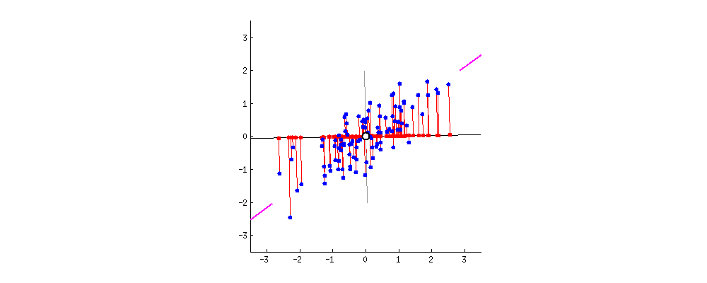

How do we go about maximizing the variance (spread of red dots) to our data features? Finding the point where variance is maximized, also minimizes error (red line lengths). Generated by user `Amoeba` on [stackexchange.com](https://stats.stackexchange.com/questions/2691/making-sense-of-principal-component-analysis-eigenvectors-eigenvalues)

All math aside, our goal is to reduce our feature set to something smaller by trying to represent our data with these new features. Just remember that highly variable data and outliers can dominate your principal components.

For simplicity let’s head back and work with our trimmed RNASeq data again to illustrate our example with PCA.

```r
# Revisit our trimmed RNAseq data
str(rnaSeq_trimmed.mx)
```

```
##  num [1:200, 1:83] 570 645 1058 831 1066 ...
##  - attr(*, "dimnames")=List of 2
##   ..$ : chr [1:200] "4932438A13Rik" "AC149090.1" "Acap1" "Actg1" ...
##   ..$ : chr [1:83] "B.fo.Sp#1.1" "B.fo.Sp#1.10" "B.fo.Sp#1.11" "B.fo.Sp#1.12" ...
```

```r
head(rnaSeq_trimmed.mx)
```

```
##               B.fo.Sp#1.1 B.fo.Sp#1.10 B.fo.Sp#1.11 B.fo.Sp#1.12 B.fo.Sp#1.13
## 4932438A13Rik    569.7773     579.2385     592.9164     536.8865     635.0124
## AC149090.1       644.7480     557.8223     553.3674     648.2539     606.1936
## Acap1           1057.5864    1005.1838     919.8546    1016.5380     993.5514
## Actg1            830.6752     727.9624     707.6084     745.2868     680.7833
## Actr2           1065.5832     959.9717     794.6162     777.2636     875.7336
## Adcy7            604.7636     624.4506     636.4203     653.7671     640.0980
##               B.fo.Sp#1.14 B.fo.Sp#1.15 B.fo.Sp#1.16 B.fo.Sp#1.2 B.fo.Sp#1.3
## 4932438A13Rik     598.8261     636.5353     725.8868    573.3140    642.1327
## AC149090.1        665.8422     516.7560     594.5449    589.1020    594.9591
## Acap1            1072.1937     894.4133    1137.9594    891.0470   1090.2824
## Actg1             658.3960     678.8104     717.8659    772.6372    710.7490
## Actr2             793.4919     791.5440     699.8189    855.5240    884.4338
## Adcy7             536.0650     697.8342     806.0956    711.4588    571.3723
##               B.fo.Sp#1.4 B.fo.Sp#1.5 B.fo.Sp#1.6 B.fo.Sp#1.8 B.fo.Sp#1.9
## 4932438A13Rik    631.4574    642.4305    596.4135    671.8535    659.1269
## AC149090.1       587.4181    529.2369    692.2272    613.0287    665.0649
## Acap1           1016.2218    998.8912   1102.8572   1137.4459   1104.4759
## Actg1            735.7610    718.8859    712.7587    748.2007    698.7134
## Actr2            819.2038    805.2705    774.3532    775.7357    900.6050
## Adcy7            599.0073    672.2183    559.9131    589.2484    682.8788
##               MF.PC#1.1 MF.PC#1.10 MF.PC#1.11 MF.PC#1.12  MF.PC#1.13 MF.PC#1.14
## 4932438A13Rik  393.4800   365.8954  302.30617  275.70109  346.839379  249.62683
## AC149090.1     976.6661   922.3370  895.96882  930.75753  947.958135 1113.44570
## Acap1            3.5541     1.0000    2.98882    8.92407    2.426142   16.93762
## Actg1          997.9503   927.1257  923.81230 1136.78335  952.949631  963.63209
## Actr2         1211.6433  1157.9388 1187.33090 1176.40370 1115.529792 1017.81999
## Adcy7          339.8439   376.4305  311.25586  373.43128  318.316544  300.62721
##               MF.PC#1.15  MF.PC#1.16   MF.PC#1.2   MF.PC#1.3   MF.PC#1.4
## 4932438A13Rik 346.705756  310.998170  379.531410  304.667795  340.221076
## AC149090.1    906.176313  951.834722  875.247377  849.712555  857.646292
## Acap1           5.091192    1.868342    4.372217    8.786354    3.713769
## Actg1         990.045756 1012.618677  939.319509  983.810869  965.292447
## Actr2         995.159747 1076.876001 1220.056613 1313.433176 1036.755020
## Adcy7         311.930620  305.788117  314.616224  290.825388  336.602718
##                 MF.PC#1.5   MF.PC#1.6   MF.PC#1.7 MF.PC#1.8   MF.PC#1.9
## 4932438A13Rik  377.557194  424.154825  413.431849  343.8695  333.421715
## AC149090.1     954.104094  990.280328  988.895582 1037.1165  907.235237
## Acap1            4.603418    1.959535    7.792995    1.0000    1.812767
## Actg1          923.475040 1072.800317  987.925154  999.5760 1016.958786
```

[output cut: 64 more lines]

```
## Adcy7               792.8699       819.3330       857.2585       797.7979
##               Tgd.Sp#1.1 Tgd.Sp#1.2 Tgd.Sp#1.3 Tgd.Sp#1.4 Tgd.Sp#1.5 Tgd.Sp#1.6
## 4932438A13Rik   821.6062   758.2418   867.6280  1013.2569   763.2004   865.1761
## AC149090.1      587.2222   585.3555   659.9449   498.4520   667.3299   615.3524
## Acap1          1027.1510   978.8446  1033.6462   917.8155  1152.0417   903.5731
## Actg1          1091.6459  1097.7903  1092.6179   947.4602  1039.4981   973.0766
## Actr2           910.7455   875.8044   750.3255   733.4402   692.9351   749.4990
## Adcy7          1076.4398  1047.9991  1107.3609   773.9304  1113.9317  1017.7921
##               Tgd.Sp#1.7 Tgd.Sp#1.8
## 4932438A13Rik   993.6486   502.5657
## AC149090.1      609.4417   852.2345
## Acap1          1100.9805   282.3661
## Actg1          1022.3616  1600.5052
## Actr2           666.1840  1005.1508
## Adcy7          1107.1333   570.8683
```

## 3.2.0 Use `PCA()` to generate our analysis

To generate our analysis of the RNAseq data, we’ll use the `FactoMineR` function `PCA()` for which there are some parameters we’ll be using that we should discuss:

- `X` a data frame of *n* rows (observations) and *p* columns (numeric variables)
- `ncp` the number of dimensions kept in the results (5 is the default)
- `scale.unit` a boolean to scale your data (TRUE by default)

Therefore, in order to work our data, we’ll have to transpose it so that our observations (samples) are correctly in rows and our variables (genes) are columns. Luckily for us, we’ve already put it into matrix form, which should make that process much simpler.

### 3.2.1 What does it mean to scale our data?

Remember that PCA is trying to maximize distance between a principal component and all of the observations supplied. Depending on the nature of your variables you may have, for instance, two different unit types like height and mass. Smaller changes in height may be matched with much larger changes in mass or just wider overall variance. This may lead the PCA algorithm to prioritize mass over height when you’d prefer they have an equal importance. By centering your mean and scaling data to unit variance, everything is compared as a **z-score**, bringing the overall variance across a variable to within ~3 standard deviations. Likewise with our gene count data, one gene may have a much lower AND smaller range of values vs another highly variable and highly expressed gene. If we want the genes to be treated equally, then we would have to scale our data.

Let’s compare PCA with and without scaling shall we?

```r
# Build a PCA of our RNAseq data with scaling applied
rnaSeq_scaled.pca <- PCA(t(rnaSeq_trimmed.mx),
                      scale.unit = TRUE,
                      ncp = 10,
                      graph = TRUE)
```

[output not shown]

```r
# Build a PCA of our RNAseq data WITHOUT scaling applied
rnaSeq_unscaled.pca <- PCA(t(rnaSeq_trimmed.mx),
                        scale.unit = FALSE, # What happens when we don't scale the data?
                        ncp = 10,
                        graph = TRUE)
```

[output not shown]

Don’t worry too much about the figures we just generated during PCA creation. We’ll revisit those in a few sections!

### 3.2.2 Our PCA object has a complex number of data pieces

Regardless of scaling, the result of our `PCA()` call produces an object with many variables we can access. Below you can see a brief description for each variable but we are most interested in a few particular ones:

- `eig` holds our dimensional data but also describes just how much each *new principal component* describes the overall variation of our data.
- `var` holds the results of all the variables. We can use these to graph and visualize our data.
- `ind$coord` will allow us to plot the coordinates of our observations along the principal components.

If we `print()` our PCA object, we’ll be able to see a brief summary of what these variables mean.

```r
# Take a look at the information inside our PCA object
print(rnaSeq_scaled.pca)
```

[output not shown]

```r
# Notice our PCA object holds our original data frame!
str(rnaSeq_scaled.pca)
```

[output not shown]

## 3.3.0 Use the eigenvalues to determine the percent variance of each component

The eigenvalues from our analysis pair with the eigenvectors (principal components) to help transform our data from the original feature set to the new set of features. While the eigenvectors may determine the directions of the new feature space, the *eigenvalue* represents the **magnitude** of the vector and in this case can be used to calculate the percent of overall variance explained by our eigenvector.

The important take-away is that we can now see just how much of our variance is explained in each new principal component. We can access this information directly from `rnaSeq_scaled.pca` or by using the function `get_eigenvalue()`. We can also plot this as a barchart instead using `factoextra::fviz_eig()`.

```r
# Look at our eigenvalues directly
rnaSeq_scaled.pca$eig
```

[output not shown]

```r
# Equivalently, use get_eigenvalue() to look at our eigenvalues
# get_eigenvalue(rnaSeq_scaled.pca)
```

### 3.3.1 Build a scree plot to look at the effect of your dimensions with `fviz_eig()`

```r
# Visualize the impact of our eigenvalues
fviz_eig(rnaSeq_scaled.pca, addlabels = TRUE) +
  theme(text = element_text(size=10))
```

[output not shown]

### 3.3.2 Most of our variance is accounted for in the first two principal components!

Looking at our eigenvalues we can see that even though 82 new PCs were generated, by the fourth PC, we get our sharp elbow. That suggests that whatever *linear* separation in our data exists, we can recreate 72% of that variability in a two-dimensional projection of coordinates from PC1 and PC2. This suggests that we can recreate a large portion of the underlying structure of our data with these two new features instead of using a 200-dimensional space!

## 3.4.0 Investigate your variables with `get_pca_var()`

Within our PCA, we can access information regarding how our original variables are transformed into the new space. This is all stored in the `var` element of our PCA object. We can extract the aspects of this using `factoextra::get_pca_var()` and visualize these to determine the quality of our variables and their representation by the new principal components.

```r
# What is the information associated with our original variables
rnaSeq.var <- get_pca_var(rnaSeq_scaled.pca)
```

[output not shown]

```r
rnaSeq.var
```

[output not shown]

### 3.4.1 What is the contribution of each variable to the new components?

Each original variable may, to some degree, influence the amount of information captured into each new principal component. When we look at each we can see the breakdown of variables, which in some cases, can reveal to us where more or less variation is found as well.

It is here now, that you’ll see the effect of using the `ncp = 10` parameter inside our original `PCA()` call.

```r
# What is the contribution of each variable?
rnaSeq.var$contrib %>% head()
```

[output not shown]

```r
# Take the contributions as a matrix
rnaSeq.var$contrib %>%
  # transpose it so the columns (dimensions) become rows
  (t) %>%
  # Convert to a dataframe
  as.data.frame(row.names = rownames(.)) %>%
  # Turn the rownames into a new column
  rownames_to_column(var = "rowNames") %>%

  # Group the rows based on rowname (which will be our dimensions)
  rowwise(rowNames) %>%

  # Summarise across each row (columns 1-200) to see the min, max, median, sd, and total contrib
  summarise(minContrib = min(c_across(1:200)),
            maxContrib = max(c_across(1:200)),
            medianContrib = median(c_across(1:200)),
            sdContrib = sd(c_across(1:200)),
            totalContrib = sum(c_across(1:200))
  )
```

[output not shown]

**How many dimensions should I get and how many do I keep?** It is at this point that we should discuss the *maximum* number of possible dimensions. Given *n* observations, and *p* features, the maximum number of dimensions after reduction is *min(n-1, p)*. In terms of how many dimensions you keep, you should consider the general rule of thumb that *at least 80%* of your variation should be accounted for by the principal components that you choose. Keep that in mind!

You may have noticed by now that we have produced 82 new principal components (see section 3.3.0 and `rnaSeq_scaled.pca$eig`), which is in line with our expectation of min(83-1, 200). We originally kept excess data on 10 of those PCs, but our scree plot, summaries and analysis of the variables suggests that we really only need 4 to explain most of the variance in our data.

### 3.4.2 Comparing the results of our scaled vs the unscaled PCA

Recall that in **section 3.2.1** we explained that depending on the kind of data you are working with, the values between variables can really vary in magnitude and range. This is especially true with RNAseq data. Let’s revisit our `rnaSeq_unscaled.pca` object and compare some of its qualities to our scaled results.

In particular, we’ll summarize the contributions for each dimension again and also make another scree plot.

```r
# 1. Make a summary of the contributions of the unscaled PCA

# What is the information associated with our original variables
rnaSeq_unscaled.var <- get_pca_var(rnaSeq_unscaled.pca)
```

[output not shown]

```r
# Take the contributions as a matrix
rnaSeq_unscaled.var$contrib %>%
  # transpose it so the columns become rows
  (t) %>%
  # Convert to a dataframe
  as.data.frame(row.names = rownames(.)) %>%
  # Turn the rownames into a new column
  rownames_to_column(var = "rowNames") %>%

  # Group the rows based on rowname (which will be our dimensions)
  rowwise(rowNames) %>%

  # Summarise across each row to see the min, max, median, and sd
  summarise(minContrib = min(c_across(1:200)),
  maxContrib = max(c_across(1:200)),
  medianContrib = median(c_across(1:200)),
  sdContrib = sd(c_across(1:200)),
  totalContrib = sum(c_across(1:200)))
```

[output not shown]

```r
# 2. Visualize the impact of our eigenvalues in the UNSCALED version
fviz_eig(rnaSeq_unscaled.pca, addlabels = TRUE) + theme(text = element_text(size=10))
```

[output not shown]

Okay a quick breakdown comparison shows that our unscaled PCA must have some variables (aka genes) dominating those components as we can see a series of higher values in the max contributions of the unscaled PCA. While this doesn’t completely change our PC contributions to **total variance**, it certainly changed how these components (and their vectors) are formed.

|  | Scaled max contribution | Unscaled max contribution to var | Scaled total contributions to var | Unscaled total contributions |
| --- | --- | --- | --- | --- |
| Dim 1 | 0.9% | 5% | 51.5% | 56.8% |
| Dim 2 | 2.2% | 16.8% | 21.3% | 23.7% |
| Dim 3 | 3.6% | 10.25% | 13% | 14.4% |
| Dim 4 | 10.8% | 39.4% | 2.4% | 2% |
| Dim 5 | 9.3% | 10.9% | 1.8% | 1% |

Let’s complete our analysis using the scaled version of our PCA.